# Risk Factor Analysis

## Outcome Variable

**Outcome Variable:** ever_swasted

## Predictor Variables

**Intervention Variable:** fhtcm

**Adjustment Set:**

- arm
- W_mage
- W_fage
- meducyrs
- feducyrs
- W_mhtcm
- W_mwtkg
- W_mbmi
- single
- delta_W_mage
- delta_W_fage
- delta_meducyrs
- delta_feducyrs
- delta_W_mhtcm
- delta_W_mwtkg
- delta_W_mbmi
- delta_single

## Stratifying Variables

The analysis was stratified on these variable(s):

- agecat
- studyid
- country

## Data Summary

| agecat | studyid | country | fhtcm | ever_swasted | n_cell | n |
| --- | --- | --- | --- | --- | --- | --- |
| 0-24 months | COHORTS | GUATEMALA | >=167 cm | 0 | 61 | 495 |
| 0-24 months | COHORTS | GUATEMALA | >=167 cm | 1 | 2 | 495 |
| 0-24 months | COHORTS | GUATEMALA | <162 cm | 0 | 273 | 495 |
| 0-24 months | COHORTS | GUATEMALA | <162 cm | 1 | 20 | 495 |
| 0-24 months | COHORTS | GUATEMALA | [162-167) cm | 0 | 130 | 495 |
| 0-24 months | COHORTS | GUATEMALA | [162-167) cm | 1 | 9 | 495 |
| 0-24 months | Keneba | GAMBIA | >=167 cm | 0 | 1012 | 1933 |
| 0-24 months | Keneba | GAMBIA | >=167 cm | 1 | 236 | 1933 |
| 0-24 months | Keneba | GAMBIA | <162 cm | 0 | 99 | 1933 |
| 0-24 months | Keneba | GAMBIA | <162 cm | 1 | 33 | 1933 |
| 0-24 months | Keneba | GAMBIA | [162-167) cm | 0 | 454 | 1933 |
| 0-24 months | Keneba | GAMBIA | [162-167) cm | 1 | 99 | 1933 |
| 0-24 months | PROBIT | BELARUS | >=167 cm | 0 | 10716 | 12537 |
| 0-24 months | PROBIT | BELARUS | >=167 cm | 1 | 1028 | 12537 |
| 0-24 months | PROBIT | BELARUS | <162 cm | 0 | 153 | 12537 |
| 0-24 months | PROBIT | BELARUS | <162 cm | 1 | 15 | 12537 |
| 0-24 months | PROBIT | BELARUS | [162-167) cm | 0 | 573 | 12537 |
| 0-24 months | PROBIT | BELARUS | [162-167) cm | 1 | 52 | 12537 |
| 0-24 months | SAS-CompFeed | INDIA | >=167 cm | 0 | 357 | 895 |
| 0-24 months | SAS-CompFeed | INDIA | >=167 cm | 1 | 50 | 895 |
| 0-24 months | SAS-CompFeed | INDIA | <162 cm | 0 | 195 | 895 |
| 0-24 months | SAS-CompFeed | INDIA | <162 cm | 1 | 31 | 895 |
| 0-24 months | SAS-CompFeed | INDIA | [162-167) cm | 0 | 221 | 895 |
| 0-24 months | SAS-CompFeed | INDIA | [162-167) cm | 1 | 41 | 895 |
| 0-24 months | SAS-FoodSuppl | INDIA | >=167 cm | 0 | 91 | 399 |
| 0-24 months | SAS-FoodSuppl | INDIA | >=167 cm | 1 | 15 | 399 |
| 0-24 months | SAS-FoodSuppl | INDIA | <162 cm | 0 | 131 | 399 |
| 0-24 months | SAS-FoodSuppl | INDIA | <162 cm | 1 | 32 | 399 |
| 0-24 months | SAS-FoodSuppl | INDIA | [162-167) cm | 0 | 110 | 399 |
| 0-24 months | SAS-FoodSuppl | INDIA | [162-167) cm | 1 | 20 | 399 |

[output cut: 60 more lines]

The following strata were considered:

- agecat: 0-24 months, studyid: COHORTS, country: GUATEMALA
- agecat: 0-24 months, studyid: Keneba, country: GAMBIA
- agecat: 0-24 months, studyid: PROBIT, country: BELARUS
- agecat: 0-24 months, studyid: SAS-CompFeed, country: INDIA
- agecat: 0-24 months, studyid: SAS-FoodSuppl, country: INDIA
- agecat: 0-6 months, studyid: COHORTS, country: GUATEMALA
- agecat: 0-6 months, studyid: Keneba, country: GAMBIA
- agecat: 0-6 months, studyid: PROBIT, country: BELARUS
- agecat: 0-6 months, studyid: SAS-CompFeed, country: INDIA
- agecat: 0-6 months, studyid: SAS-FoodSuppl, country: INDIA
- agecat: 6-24 months, studyid: COHORTS, country: GUATEMALA
- agecat: 6-24 months, studyid: Keneba, country: GAMBIA
- agecat: 6-24 months, studyid: PROBIT, country: BELARUS
- agecat: 6-24 months, studyid: SAS-CompFeed, country: INDIA
- agecat: 6-24 months, studyid: SAS-FoodSuppl, country: INDIA

### Dropped Strata

Some strata were dropped due to rare outcomes:

- agecat: 0-24 months, studyid: COHORTS, country: GUATEMALA
- agecat: 0-6 months, studyid: COHORTS, country: GUATEMALA
- agecat: 0-6 months, studyid: SAS-FoodSuppl, country: INDIA
- agecat: 6-24 months, studyid: COHORTS, country: GUATEMALA
- agecat: 6-24 months, studyid: PROBIT, country: BELARUS

## Methods Detail

We’re interested in the causal parameters $E[Y_a]$ for all values of $a \in \mathcal{A}$. These parameters represent the mean outcome if, possibly contrary to fact, we intervened to set all units to have $A=a$. Under the randomization and positivity assumptions, these are identified by the statistical parameters $\psi_a=E_W[E_{Y|A,W}(Y|A=a,W)]$. In addition, we’re interested in the mean of $Y$, $E[Y]$ under no intervention (the observed mean). We will estimate these parameters by using SuperLearner to fit the relevant likelihood factors – $E_{Y|A,W}(Y|A=a,W)$ and $p(A=a|W)$, and then updating our likelihood fit using a joint TMLE.

For unadjusted analyses ($W=\{\}$), initial likelihoods were estimated using Lrnr_glm to estimate the simple $E(Y|A)$ and Lrnr_mean to estimate $p(A)$. For adjusted analyses, a small library containing Lrnr_glmnet, Lrnr_xgboost, and Lrnr_mean was used.

Having estimated these parameters, we will then use the delta method to estimate relative risks and attributable risks relative to a prespecified baseline level of $A$.

# Results Detail

## Results Plots

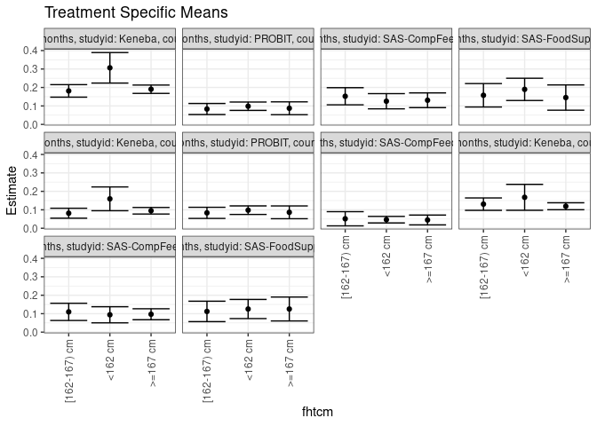

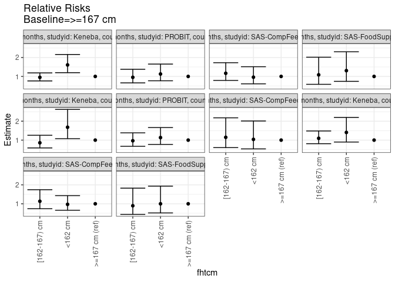

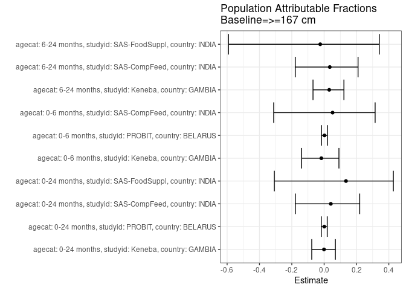

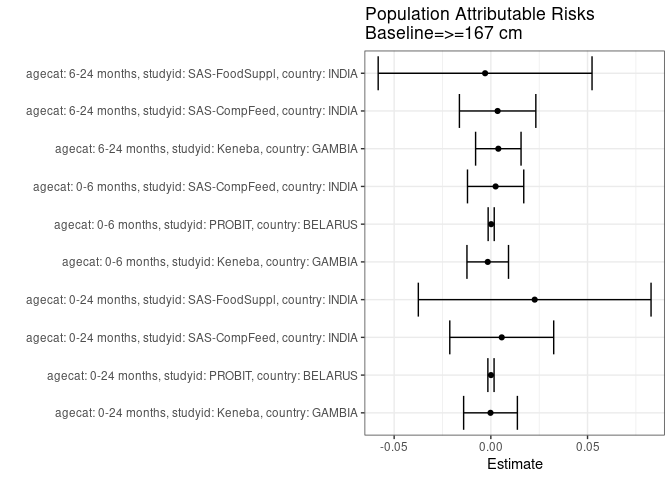

## Results Table

### Parameter: TSM

| agecat | studyid | country | intervention_level | baseline_level | estimate | ci_lower | ci_upper |
| --- | --- | --- | --- | --- | --- | --- | --- |
| 0-24 months | Keneba | GAMBIA | >=167 cm | NA | 0.1905507 | 0.1679835 | 0.2131178 |
| 0-24 months | Keneba | GAMBIA | <162 cm | NA | 0.3064749 | 0.2237883 | 0.3891614 |
| 0-24 months | Keneba | GAMBIA | [162-167) cm | NA | 0.1813537 | 0.1474853 | 0.2152222 |
| 0-24 months | PROBIT | BELARUS | >=167 cm | NA | 0.0872726 | 0.0525618 | 0.1219834 |
| 0-24 months | PROBIT | BELARUS | <162 cm | NA | 0.0984611 | 0.0757566 | 0.1211655 |
| 0-24 months | PROBIT | BELARUS | [162-167) cm | NA | 0.0832057 | 0.0532488 | 0.1131627 |
| 0-24 months | SAS-CompFeed | INDIA | >=167 cm | NA | 0.1306765 | 0.0907730 | 0.1705800 |
| 0-24 months | SAS-CompFeed | INDIA | <162 cm | NA | 0.1254014 | 0.0841775 | 0.1666253 |
| 0-24 months | SAS-CompFeed | INDIA | [162-167) cm | NA | 0.1523790 | 0.1059857 | 0.1987723 |
| 0-24 months | SAS-FoodSuppl | INDIA | >=167 cm | NA | 0.1452471 | 0.0767700 | 0.2137243 |
| 0-24 months | SAS-FoodSuppl | INDIA | <162 cm | NA | 0.1897008 | 0.1294897 | 0.2499119 |
| 0-24 months | SAS-FoodSuppl | INDIA | [162-167) cm | NA | 0.1576088 | 0.0940621 | 0.2211555 |
| 0-6 months | Keneba | GAMBIA | >=167 cm | NA | 0.0949431 | 0.0771982 | 0.1126880 |
| 0-6 months | Keneba | GAMBIA | <162 cm | NA | 0.1594403 | 0.0949367 | 0.2239439 |
| 0-6 months | Keneba | GAMBIA | [162-167) cm | NA | 0.0815049 | 0.0544976 | 0.1085121 |
| 0-6 months | PROBIT | BELARUS | >=167 cm | NA | 0.0864449 | 0.0518168 | 0.1210730 |
| 0-6 months | PROBIT | BELARUS | <162 cm | NA | 0.0980057 | 0.0748247 | 0.1211866 |
| 0-6 months | PROBIT | BELARUS | [162-167) cm | NA | 0.0834275 | 0.0532756 | 0.1135795 |
| 0-6 months | SAS-CompFeed | INDIA | >=167 cm | NA | 0.0448272 | 0.0182166 | 0.0714378 |
| 0-6 months | SAS-CompFeed | INDIA | <162 cm | NA | 0.0465530 | 0.0288621 | 0.0642440 |
| 0-6 months | SAS-CompFeed | INDIA | [162-167) cm | NA | 0.0514119 | 0.0129676 | 0.0898562 |
| 6-24 months | Keneba | GAMBIA | >=167 cm | NA | 0.1193077 | 0.1004350 | 0.1381803 |
| 6-24 months | Keneba | GAMBIA | <162 cm | NA | 0.1676375 | 0.0974551 | 0.2378200 |
| 6-24 months | Keneba | GAMBIA | [162-167) cm | NA | 0.1307341 | 0.0970937 | 0.1643745 |
| 6-24 months | SAS-CompFeed | INDIA | >=167 cm | NA | 0.0969725 | 0.0672318 | 0.1267133 |
| 6-24 months | SAS-CompFeed | INDIA | <162 cm | NA | 0.0941080 | 0.0504002 | 0.1378159 |
| 6-24 months | SAS-CompFeed | INDIA | [162-167) cm | NA | 0.1099628 | 0.0633185 | 0.1566071 |
| 6-24 months | SAS-FoodSuppl | INDIA | >=167 cm | NA | 0.1254139 | 0.0607234 | 0.1901044 |
| 6-24 months | SAS-FoodSuppl | INDIA | <162 cm | NA | 0.1253822 | 0.0735466 | 0.1772177 |
| 6-24 months | SAS-FoodSuppl | INDIA | [162-167) cm | NA | 0.1122494 | 0.0569639 | 0.1675349 |

### Parameter: E(Y)

| agecat | studyid | country | intervention_level | baseline_level | estimate | ci_lower | ci_upper |
| --- | --- | --- | --- | --- | --- | --- | --- |
| 0-24 months | Keneba | GAMBIA | NA | NA | 0.1903777 | 0.1728714 | 0.2078839 |
| 0-24 months | PROBIT | BELARUS | NA | NA | 0.0873415 | 0.0532447 | 0.1214382 |
| 0-24 months | SAS-CompFeed | INDIA | NA | NA | 0.1363128 | 0.1083079 | 0.1643178 |
| 0-24 months | SAS-FoodSuppl | INDIA | NA | NA | 0.1679198 | 0.1311966 | 0.2046430 |
| 0-6 months | Keneba | GAMBIA | NA | NA | 0.0933333 | 0.0796017 | 0.1070650 |
| 0-6 months | PROBIT | BELARUS | NA | NA | 0.0866236 | 0.0525316 | 0.1207156 |
| 0-6 months | SAS-CompFeed | INDIA | NA | NA | 0.0472973 | 0.0247949 | 0.0697997 |
| 6-24 months | Keneba | GAMBIA | NA | NA | 0.1231767 | 0.1082011 | 0.1381522 |
| 6-24 months | SAS-CompFeed | INDIA | NA | NA | 0.1004785 | 0.0697945 | 0.1311624 |
| 6-24 months | SAS-FoodSuppl | INDIA | NA | NA | 0.1224490 | 0.0899572 | 0.1549408 |

### Parameter: RR

| agecat | studyid | country | intervention_level | baseline_level | estimate | ci_lower | ci_upper |
| --- | --- | --- | --- | --- | --- | --- | --- |
| 0-24 months | Keneba | GAMBIA | >=167 cm | >=167 cm | 1.0000000 | 1.0000000 | 1.000000 |
| 0-24 months | Keneba | GAMBIA | <162 cm | >=167 cm | 1.6083643 | 1.1978817 | 2.159508 |
| 0-24 months | Keneba | GAMBIA | [162-167) cm | >=167 cm | 0.9517350 | 0.7628722 | 1.187354 |
| 0-24 months | PROBIT | BELARUS | >=167 cm | >=167 cm | 1.0000000 | 1.0000000 | 1.000000 |
| 0-24 months | PROBIT | BELARUS | <162 cm | >=167 cm | 1.1282010 | 0.7702987 | 1.652395 |
| 0-24 months | PROBIT | BELARUS | [162-167) cm | >=167 cm | 0.9533999 | 0.6599287 | 1.377378 |
| 0-24 months | SAS-CompFeed | INDIA | >=167 cm | >=167 cm | 1.0000000 | 1.0000000 | 1.000000 |
| 0-24 months | SAS-CompFeed | INDIA | <162 cm | >=167 cm | 0.9596323 | 0.6086986 | 1.512890 |
| 0-24 months | SAS-CompFeed | INDIA | [162-167) cm | >=167 cm | 1.1660781 | 0.7883882 | 1.724706 |
| 0-24 months | SAS-FoodSuppl | INDIA | >=167 cm | >=167 cm | 1.0000000 | 1.0000000 | 1.000000 |
| 0-24 months | SAS-FoodSuppl | INDIA | <162 cm | >=167 cm | 1.3060554 | 0.7406633 | 2.303045 |
| 0-24 months | SAS-FoodSuppl | INDIA | [162-167) cm | >=167 cm | 1.0851078 | 0.5840669 | 2.015966 |
| 0-6 months | Keneba | GAMBIA | >=167 cm | >=167 cm | 1.0000000 | 1.0000000 | 1.000000 |
| 0-6 months | Keneba | GAMBIA | <162 cm | >=167 cm | 1.6793238 | 1.0755240 | 2.622097 |
| 0-6 months | Keneba | GAMBIA | [162-167) cm | >=167 cm | 0.8584599 | 0.5868612 | 1.255754 |
| 0-6 months | PROBIT | BELARUS | >=167 cm | >=167 cm | 1.0000000 | 1.0000000 | 1.000000 |
| 0-6 months | PROBIT | BELARUS | <162 cm | >=167 cm | 1.1337358 | 0.7725400 | 1.663806 |
| 0-6 months | PROBIT | BELARUS | [162-167) cm | >=167 cm | 0.9650952 | 0.6731325 | 1.383693 |
| 0-6 months | SAS-CompFeed | INDIA | >=167 cm | >=167 cm | 1.0000000 | 1.0000000 | 1.000000 |
| 0-6 months | SAS-CompFeed | INDIA | <162 cm | >=167 cm | 1.0384998 | 0.5365772 | 2.009928 |
| 0-6 months | SAS-CompFeed | INDIA | [162-167) cm | >=167 cm | 1.1468904 | 0.6042697 | 2.176772 |
| 6-24 months | Keneba | GAMBIA | >=167 cm | >=167 cm | 1.0000000 | 1.0000000 | 1.000000 |
| 6-24 months | Keneba | GAMBIA | <162 cm | >=167 cm | 1.4050861 | 0.8981254 | 2.198209 |
| 6-24 months | Keneba | GAMBIA | [162-167) cm | >=167 cm | 1.0957730 | 0.8099774 | 1.482410 |
| 6-24 months | SAS-CompFeed | INDIA | >=167 cm | >=167 cm | 1.0000000 | 1.0000000 | 1.000000 |
| 6-24 months | SAS-CompFeed | INDIA | <162 cm | >=167 cm | 0.9704610 | 0.6581696 | 1.430930 |
| 6-24 months | SAS-CompFeed | INDIA | [162-167) cm | >=167 cm | 1.1339586 | 0.7377857 | 1.742867 |
| 6-24 months | SAS-FoodSuppl | INDIA | >=167 cm | >=167 cm | 1.0000000 | 1.0000000 | 1.000000 |
| 6-24 months | SAS-FoodSuppl | INDIA | <162 cm | >=167 cm | 0.9997470 | 0.5170754 | 1.932975 |
| 6-24 months | SAS-FoodSuppl | INDIA | [162-167) cm | >=167 cm | 0.8950316 | 0.4389015 | 1.825197 |

### Parameter: PAR

| agecat | studyid | country | intervention_level | baseline_level | estimate | ci_lower | ci_upper |
| --- | --- | --- | --- | --- | --- | --- | --- |
| 0-24 months | Keneba | GAMBIA | >=167 cm | NA | -0.0001730 | -0.0140705 | 0.0137245 |
| 0-24 months | PROBIT | BELARUS | >=167 cm | NA | 0.0000688 | -0.0015348 | 0.0016725 |
| 0-24 months | SAS-CompFeed | INDIA | >=167 cm | NA | 0.0056364 | -0.0212301 | 0.0325028 |
| 0-24 months | SAS-FoodSuppl | INDIA | >=167 cm | NA | 0.0226727 | -0.0374970 | 0.0828424 |
| 0-6 months | Keneba | GAMBIA | >=167 cm | NA | -0.0016098 | -0.0123526 | 0.0091330 |
| 0-6 months | PROBIT | BELARUS | >=167 cm | NA | 0.0001787 | -0.0013922 | 0.0017496 |
| 0-6 months | SAS-CompFeed | INDIA | >=167 cm | NA | 0.0024701 | -0.0120754 | 0.0170156 |
| 6-24 months | Keneba | GAMBIA | >=167 cm | NA | 0.0038690 | -0.0078826 | 0.0156206 |
| 6-24 months | SAS-CompFeed | INDIA | >=167 cm | NA | 0.0035060 | -0.0162520 | 0.0232639 |
| 6-24 months | SAS-FoodSuppl | INDIA | >=167 cm | NA | -0.0029649 | -0.0582574 | 0.0523275 |

### Parameter: PAF

| agecat | studyid | country | intervention_level | baseline_level | estimate | ci_lower | ci_upper |
| --- | --- | --- | --- | --- | --- | --- | --- |
| 0-24 months | Keneba | GAMBIA | >=167 cm | NA | -0.0009087 | -0.0766345 | 0.0694908 |
| 0-24 months | PROBIT | BELARUS | >=167 cm | NA | 0.0007883 | -0.0178581 | 0.0190930 |
| 0-24 months | SAS-CompFeed | INDIA | >=167 cm | NA | 0.0413487 | -0.1782904 | 0.2200460 |
| 0-24 months | SAS-FoodSuppl | INDIA | >=167 cm | NA | 0.1350208 | -0.3079377 | 0.4279629 |
| 0-6 months | Keneba | GAMBIA | >=167 cm | NA | -0.0172479 | -0.1390405 | 0.0915219 |
| 0-6 months | PROBIT | BELARUS | >=167 cm | NA | 0.0020630 | -0.0165197 | 0.0203060 |
| 0-6 months | SAS-CompFeed | INDIA | >=167 cm | NA | 0.0522250 | -0.3119400 | 0.3153060 |
| 6-24 months | Keneba | GAMBIA | >=167 cm | NA | 0.0314103 | -0.0688608 | 0.1222748 |
| 6-24 months | SAS-CompFeed | INDIA | >=167 cm | NA | 0.0348926 | -0.1787116 | 0.2097878 |
| 6-24 months | SAS-FoodSuppl | INDIA | >=167 cm | NA | -0.0242136 | -0.5915745 | 0.3408958 |